# Análise Estatística de Dados - Aluguéis Distrito Federal

Suênia Araújo, Glaucia Calazans, Rutiele Oliveira, Gustavo Fonseca e Gerciane Cabral

2024-06-13

# Análise Estatística de Dados - DF Imovéis

### Base de dados - Web Scraping https://www.dfimoveis.com.br/aluguel/df/todos/apartamento

### **Baixando as Bibliotecas**

“Este código em R Markdown utiliza o pacote pacman para instalar e carregar diversos pacotes essenciais para análise de dados em R. O pacman simplifica o processo de gerenciamento de pacotes, garantindo que todos os pacotes necessários estejam disponíveis antes da execução do código. Entre os pacotes carregados estão o lubridate para manipulação de datas, ggplot2 para criação de gráficos, dplyr para manipulação de dados, httr para requisições HTTP, BiocManager para instalar pacotes do Bioconductor, rvest para web scraping e stringr para manipulação de strings.”

```r
if (!require(pacman)) install.packages("pacman")
pacman::p_load(lubridate, ggplot2, dplyr, ggplot, httr, BiocManager,rvest, stringr )
```

### **Parte 1: Web Scraping da Base de Dados**

O código em R desenvolvido realiza web scraping do site dfimoveis.com.br para extrair informações sobre apartamentos disponíveis para aluguel no Distrito Federal. Ele utiliza a função `lapply` para aplicar a função `remove_non_numeric` a múltiplas colunas do data frame, removendo caracteres não numéricos e convertendo os valores para formato numérico onde aplicável, como preço, área em metros quadrados, número de quartos, suítes, vagas de garagem e CRECI.

Além disso, o script faz uso de pacotes como `rvest` para manipulação de HTML, `stringr` para operações com strings e `dplyr` para transformações e filtragens de dados. Após a extração e limpeza dos dados, os resultados são consolidados em um data frame único e exportados para um arquivo CSV chamado `apartamentos.csv`. O código finaliza mostrando o número total de apartamentos encontrados e um resumo estatístico dos dados coletados, facilitando análises posteriores do mercado imobiliário na região.

```r
# URL base e número da página inicial
url_base <- 'https://www.dfimoveis.com.br/aluguel/df/todos/apartamento'
pagina_atual <- 1
total_apartamentos <- 0

# Bairros a serem procurados
bairros <- c(
  "AGUAS CLARAS", "TAGUATINGA", "GUARA", "SAMAMBAIA",
  "NUCLEO BANDEIRANTE", "RIACHO FUNDO", "SOBRADINHO", "CEILANDIA", "VICENTE PIRES",
  "CRUZEIRO", "GAMA", "PLANALTINA", "SANTA MARIA", "JARDIM BOTANICO",
  "PARANOA", "CANDANGOLANDIA", "RECANTO DAS EMAS", "SAO SEBASTIAO", "SETOR INDUSTRIAL",
  "VARJAO", "ALPHAVILLE", "AGUAS LINDAS DE GOIAS", "FORMOSA", "LUZIANIA",
  "ASA NORTE", "ASA SUL", "NOROESTE", "SUDOESTE", "PARK SUL",
  "LAGO NORTE", "JARDINS MANGUEIRAL", "JARDIM BOTANICO", "OCTOGONAL", "LAGO SUL",
  "GRANJA DO TORTO", "PARK WAY", "SETOR MILITAR URBANO", "SIG", "VALPARAISO DE GOIAS"
)

# Lista para armazenar os dados dos apartamentos
apartamentos_data <- list()

while(TRUE) {
  # Faz a solicitação HTTP para a página atual
  response <- GET(paste0(url_base, "?pagina=", pagina_atual))

  # Verifica se a solicitação foi bem-sucedida
  if(status_code(response) != 200) {
    print(paste("Erro ao acessar a página", pagina_atual, ". Status code:", status_code(response)))
    break
  }

  site <- read_html(content(response, as = "text"))

  # Encontra todos os elementos que representam os apartamentos na página
  apartamentos <- site %>% html_nodes('a.new-card')

  # Se não houver mais apartamentos, sai do loop
  if(length(apartamentos) == 0) {
    break
  }

  # Loop através dos apartamentos na página atual
  for(apartamento in apartamentos) {
    # Extrai os dados relevantes de cada apartamento
    endereco_texto <- apartamento %>% html_node('h2.new-title.phrase') %>% html_text(trim = TRUE)
    preco_texto <- apartamento %>% html_node('div.new-price') %>% html_nodes('h4') %>% html_text(trim = TRUE)
    detalhes_elem <- apartamento %>% html_node('ul.new-details-ul')
    creci <- apartamento %>% html_node('div.creci p') %>% html_text(trim = TRUE)

    # Procura por cada bairro na string do endereço
    bairro <- NA
    for(b in bairros) {
      if(str_detect(endereco_texto, b)) {
        bairro <- b
        break
      }
    }

    preco <- if(length(preco_texto) > 0) preco_texto[1] else NA
    valor_metro_quadrado <- if(length(preco_texto) > 1) preco_texto[2] else NA

    metros_quadrados <- quartos <- suites <- vagas <- NA

    # Verifica se os detalhes do apartamento foram encontrados antes de extrair o texto
    if(!is.null(detalhes_elem)) {
      metros_quadrados <- detalhes_elem %>% html_node('li.m-area') %>% html_text(trim = TRUE)
      detalhes <- detalhes_elem %>% html_nodes('li')
      for(item in detalhes) {
        texto <- item %>% html_node('span') %>% html_text(trim = TRUE)
        if(str_detect(texto, regex('quarto', ignore_case = TRUE))) {
          quartos <- texto
        } else if(str_detect(texto, regex('suíte', ignore_case = TRUE))) {
          suites <- texto
        } else if(str_detect(texto, regex('vaga', ignore_case = TRUE))) {
          vagas <- texto
        }
      }
    }

    # Adiciona os dados do apartamento à lista de apartamentos
    apartamentos_data <- append(apartamentos_data, list(data.frame(
      Endereco = endereco_texto,
      Bairro = bairro,
      Preco = preco,
      Valor_m2 = valor_metro_quadrado,
      Metros_Quadrados = metros_quadrados,
      Quartos = quartos,
      Suites = suites,
      Vagas = vagas,
      CRECI = creci,
      stringsAsFactors = FALSE
    )))

    # Incrementa o contador de apartamentos
    total_apartamentos <- total_apartamentos + 1
  }

  # Incrementa o número da página atual
  pagina_atual <- pagina_atual + 1
}

# Converte a lista de data frames em um único data frame
df <- bind_rows(apartamentos_data)

# Função para remover caracteres não numéricos
remove_non_numeric <- function(text) {
  return(gsub("\\D", "", text))
}

# Colunas a serem limpas
cols_to_clean <- c("Preco", "Valor_m2", "Metros_Quadrados", "Quartos", "Suites", "Vagas", "CRECI")

# Aplicar a função para remover caracteres não numéricos e converter para numérico
df[cols_to_clean] <- lapply(df[cols_to_clean], function(col) as.numeric(remove_non_numeric(col)))

# Converter o dataframe resultante em um data frame regular
df <- as.data.frame(df)

# Salva o DataFrame em um arquivo CSV
write.csv(df, "apartamentos.csv", row.names = FALSE)

# Imprime o total de apartamentos encontrados
print(paste("Total de apartamentos encontrados:", total_apartamentos))
```

```
## [1] "Total de apartamentos encontrados: 2114"
```

```r
# Imprime um resumo estatístico dos dados
print(summary(df))
```

```
##    Endereco            Bairro              Preco            Valor_m2
##  Length:2114        Length:2114        Min.   :    400   Min.   :     2.0
##  Class :character   Class :character   1st Qu.:   1300   1st Qu.:    26.0
##  Mode  :character   Mode  :character   Median :   2100   Median :    39.0
##                                        Mean   :   7084   Mean   :   168.4
##                                        3rd Qu.:   3900   3rd Qu.:    54.0
##                                        Max.   :7000000   Max.   :160000.0
##
##  Metros_Quadrados    Quartos          Suites          Vagas
##  Min.   :  0.00   Min.   :1.000   Min.   :1.000   Min.   :  1.000
##  1st Qu.: 36.00   1st Qu.:1.000   1st Qu.:1.000   1st Qu.:  1.000
##  Median : 55.00   Median :2.000   Median :1.000   Median :  1.000
##  Mean   : 71.72   Mean   :1.923   Mean   :1.368   Mean   :  1.454
##  3rd Qu.: 79.00   3rd Qu.:2.000   3rd Qu.:1.000   3rd Qu.:  1.000
##  Max.   :804.00   Max.   :5.000   Max.   :5.000   Max.   :192.000
##                   NA's   :9       NA's   :1073    NA's   :754
##      CRECI
##  Min.   :  111
##  1st Qu.: 6551
##  Median :11798
##  Mean   :14125
##  3rd Qu.:23141
##  Max.   :31591
##
```

### **Parte 2: Manipulação, Limpeza e Transformação de Dados**

Esse trecho de código faz a limpeza dos outliers e tambem substitui todos os valores faltantes (NA) por 0. Utilizamos a função filter para remover registros com valores extremos em várias colunas (Vagas, Metros_Quadrados, Preco, Valor_m2) Em seguida, a função mutate_all substitui todos os valores NA em todas as colunas por 0. Finalmente, summary(df_limpo) é usado para verificar a distribuição dos dados após a limpeza.

```r
# Remover outliers e substituir NA por 0
df_limpo <- df %>%
  filter(Vagas <= 10) %>%                  # Coluna Vagas: remover valores acima de 10
  filter(Metros_Quadrados >= 3) %>%        # Coluna Metros_Quadrados: remover valores abaixo de 3m²
  filter(Preco <= 80000) %>%               # Coluna Preco: remover valores acima de 80.000,00
  filter(Valor_m2 > 2) %>%                 # Coluna Valor_m2: remover valores menores ou iguais a 2
  mutate_all(~replace(., is.na(.), 0))     # Substituir NA por 0 em todas as colunas

# Verificar a distribuição dos dados após a limpeza
summary(df_limpo)
```

```
##    Endereco            Bairro              Preco          Valor_m2
##  Length:1354        Length:1354        Min.   :  500   Min.   :  8.00
##  Class :character   Class :character   1st Qu.: 1752   1st Qu.: 34.00
##  Mode  :character   Mode  :character   Median : 2770   Median : 44.00
##                                        Mean   : 3957   Mean   : 49.29
##                                        3rd Qu.: 5200   3rd Qu.: 60.00
##                                        Max.   :29000   Max.   :173.00
##  Metros_Quadrados    Quartos          Suites           Vagas
##  Min.   : 10.0    Min.   :0.000   Min.   :0.0000   Min.   :1.000
##  1st Qu.: 44.0    1st Qu.:1.000   1st Qu.:0.0000   1st Qu.:1.000
##  Median : 64.0    Median :2.000   Median :1.0000   Median :1.000
##  Mean   : 83.3    Mean   :2.129   Mean   :0.9254   Mean   :1.312
##  3rd Qu.: 97.0    3rd Qu.:3.000   3rd Qu.:1.0000   3rd Qu.:1.000
##  Max.   :804.0    Max.   :5.000   Max.   :5.0000   Max.   :5.000
##      CRECI
##  Min.   :  208
##  1st Qu.: 6095
##  Median :11983
##  Mean   :14155
##  3rd Qu.:23649
##  Max.   :31240
```

### Contar o número de apartamentos por bairro em todos os bairros

Esse trecho agrupa os dados pelo valor da coluna Bairro e conta o número de registros (apartamentos) em cada bairro. O resultado é armazenado em contagem_por_bairro. Ordena os bairros pela contagem de apartamentos em ordem decrescente para facilitar a visualização. Cria um gráfico de barras para visualizar o número de apartamentos por bairro. Adciona rótulos informativos e formatação do gráfico para facilitar a leitura.

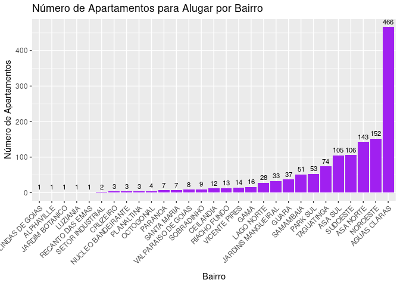

```r
# Contar o número de apartamentos por bairro em todos os bairros
contagem_por_bairro <- df_limpo %>%
  group_by(Bairro) %>%
  summarise(Numero_de_Apartamentos = n())

# Ordenar os bairros pela contagem de apartamentos
contagem_por_bairro <- contagem_por_bairro[order(contagem_por_bairro$Numero_de_Apartamentos, decreasing = TRUE), ]

# Plotar o gráfico de barras com rótulos de quantidade em cada barra
ggplot(contagem_por_bairro, aes(x = reorder(Bairro, Numero_de_Apartamentos), y = Numero_de_Apartamentos)) +
  geom_bar(stat = "identity", fill = "purple") +
  geom_text(aes(label = Numero_de_Apartamentos), vjust = -0.5, size = 3) +  # Adicionar rótulos de quantidade
  labs(title = "Número de Apartamentos para Alugar por Bairro", x = "Bairro", y = "Número de Apartamentos") +
  theme(axis.text.x = element_text(angle = 45, hjust = 1))
```

### Média de Preço por Bairro

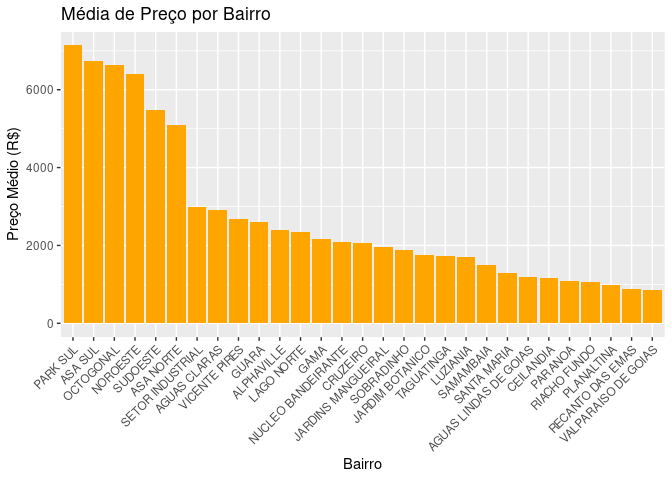

```r
# Média de preço por bairro
media_preco_por_bairro <- aggregate(Preco ~ Bairro, data = df_limpo, FUN = mean)
media_preco_por_bairro <- media_preco_por_bairro[order(media_preco_por_bairro$Preco, decreasing = TRUE), ]

# Gráfico de barras da média de preço por bairro
ggplot(media_preco_por_bairro, aes(x = reorder(Bairro, -Preco), y = Preco)) +
  geom_bar(stat = "identity", fill = "orange") +  # Define a cor das barras como laranja
  labs(title = "Média de Preço por Bairro",
       x = "Bairro", y = "Preço Médio (R$)",
       fill = "Bairro") +
  theme(axis.text.x = element_text(angle = 45, hjust = 1))
```

### Distribuição de Metros Quadrados por Bairro em Brasília

Análise da Distribuição de Metros Quadrados dos Apartamentos em Brasília por Bairro Utiliza-se o operador %>% e filtro (filter) para serem mostrados apenas os bairros da região de Brasília. Cria um boxplot (ggplot) que mostra a distribuição de metros quadrados por bairro em Brasília. Rotula os eixos (labs) e o texto do eixo é formatado (theme(axis.text.t)).

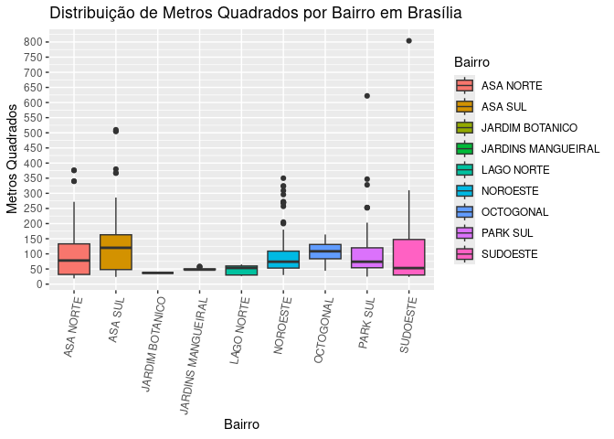

```r
#VALORES DE ALUGUEL DE BRASILIA E CIDADES SATELITES
# Criar uma nova variável 'Regiao' para agrupar os bairros em 'Brasilia' e 'Cidades Satelites'
df_limpo$Regiao <- ifelse(df_limpo$Bairro %in% c("ASA NORTE", "ASA SUL", "NOROESTE", "SUDOESTE", "PARK SUL", "LAGO NORTE", "JARDINS MANGUEIRAL", "JARDIM BOTANICO", "OCTOGONAL", "LAGO SUL", "GRANJA DO TORTO", "PARK WAY", "SETOR MILITAR URBANO", "SIG"),
                          "Brasilia", "Cidades Satelites")


# Filtrar os dados para incluir apenas os bairros da região de Brasília
df_brasilia <- df_limpo %>%
  filter(Regiao == "Brasilia")

# Gráfico de Caixa (Boxplot) para a região de Brasília
ggplot(df_brasilia, aes(x = Bairro, y = Metros_Quadrados, fill = Bairro)) +
  geom_boxplot() +
  scale_y_continuous(breaks = seq(0, max(df_brasilia$Metros_Quadrados, na.rm = TRUE), by = 50)) +
  labs(title = "Distribuição de Metros Quadrados por Bairro em Brasília",
       x = "Bairro", y = "Metros Quadrados", fill = "Bairro") +
  theme(axis.text.x = element_text(angle = 80, hjust = 1))
```

### Análise de Relação entre Preço e Tamanho (metros quadrados)

Cria um scatterplot (ggplot) que mostra a relação entre o tamanho (metros quadrados) e o preço dos apartamentos. Usa geom_point para os pontos de dados e geom_smooth para traçar uma linha de tendência linear (method = “lm”). Define rótulos para os eixos (labs) e ajusta as escalas dos eixos (scale_x_continuous e scale_y_continuous).

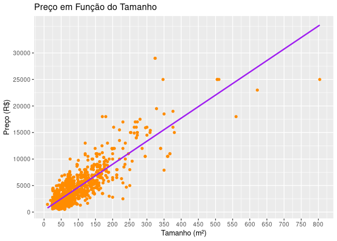

```r
# Scatterplot de preço por tamanho (metros quadrados)
ggplot(df_limpo, aes(x = Metros_Quadrados, y = Preco)) +
  geom_point(color = "darkorange") +
  geom_smooth(method = "lm", se = FALSE, color = "purple") +
  labs(title = "Preço em Função do Tamanho",
       x = "Tamanho (m²)", y = "Preço (R$)") +
  scale_x_continuous(breaks = seq(0, ceiling(max(df_limpo$Metros_Quadrados) / 50) * 50, by = 50)) +
  scale_y_continuous(breaks = seq(0, ceiling(max(df_limpo$Preco) / 5000) * 5000, by = 5000))
```

### Preços de Aluguel por Região

Este código analisa os preços de aluguel em Brasília e cidades satélites do Distrito Federal. Primeiramente, agrupa os bairros em duas categorias: ‘Brasília’ e ‘Cidades Satélites’ e em seguida, cria um gráfico de boxplot para comparar os preços de aluguel entre essas regiões. A análise busca identificar diferenças nos preços, variações dentro de cada região e possíveis outliers.

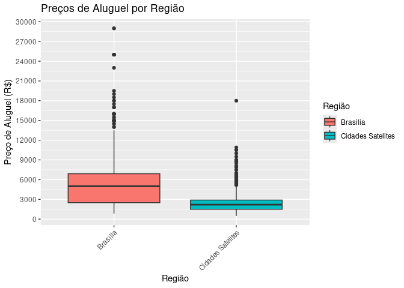

```r
#VALORES DE ALUGUEL DE BRASILIA E CIDADES SATELITES
# Criar uma nova variável 'Regiao' para agrupar os bairros em 'Brasilia' e 'Cidades Satelites'
df_limpo$Regiao <- ifelse(df_limpo$Bairro %in% c("ASA NORTE", "ASA SUL", "NOROESTE", "SUDOESTE", "PARK SUL", "LAGO NORTE", "JARDINS MANGUEIRAL", "JARDIM BOTANICO", "OCTOGONAL", "LAGO SUL", "GRANJA DO TORTO", "PARK WAY", "SETOR MILITAR URBANO", "SIG"),
                          "Brasilia", "Cidades Satelites")

# Definir intervalos de 5 em 5 mil para o eixo Y
intervalos_y <- seq(0, ceiling(max(df_limpo$Preco) / 3000) * 3000, by = 3000)

# Boxplot de preços por aluguel por Região (Brasília ou Cidades Satélites)
ggplot(df_limpo, aes(x = Regiao, y = Preco, fill = Regiao)) +
  geom_boxplot() +
  scale_y_continuous(breaks = intervalos_y) +  # Definir os intervalos de 5 em 5 mil para o eixo Y
  labs(title = "Preços de Aluguel por Região",
       x = "Região", y = "Preço de Aluguel (R$)",
       fill = "Região") +
  theme(axis.text.x = element_text(angle = 45, hjust = 1))
```

### Quantidade de Apartamentos com 1 ou 0 Quartos por Bairro em Brasília

Este trecho de código filtra os apartamentos em Brasília com 1 ou 0 quartos, em seguida, conta o número de apartamentos com essas características por bairro. Por fim, cria um gráfico de barras mostrando a distribuição desses apartamentos por bairro, com o objetivo de identificar quais bairros têm mais apartamentos com 1 ou 0 quartos na região de Brasília.

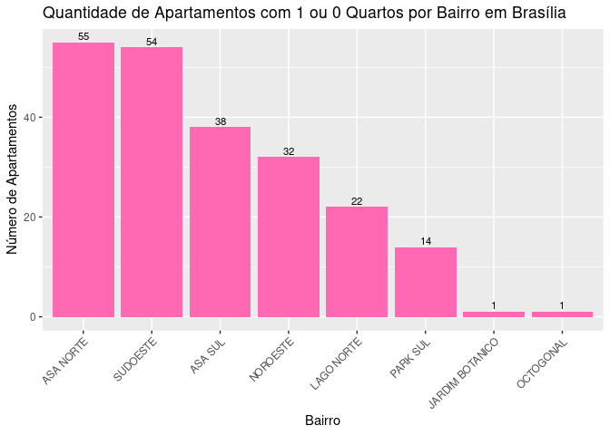

```r
# Filtrar apenas os apartamentos com 1 ou 0 quartos em Brasília
df_apartamentos_1_0_quartos_brasilia <- df_limpo %>%
  filter(Regiao == "Brasilia" & (Quartos == "1" | Quartos == "0"))

# Contar o número de apartamentos com 1 ou 0 quartos por bairro
contagem_quartos_brasilia <- df_apartamentos_1_0_quartos_brasilia %>%
  group_by(Bairro) %>%
  summarise(Numero_Apartamentos = n())

# Gráfico de barras com quantidade de apartamentos com 1 ou 0 quartos por bairro
ggplot(contagem_quartos_brasilia, aes(x = reorder(Bairro, -Numero_Apartamentos), y = Numero_Apartamentos)) +
  geom_bar(stat = "identity", fill = "hotpink") +
  geom_text(aes(label = Numero_Apartamentos), vjust = -0.3, size = 3) +  # Adicionar labels com a quantidade
  labs(title = "Quantidade de Apartamentos com 1 ou 0 Quartos por Bairro em Brasília",
       x = "Bairro", y = "Número de Apartamentos",
       fill = "Bairro") +
  theme(axis.text.x = element_text(angle = 45, hjust = 1))
```